# Climate Trends in Barrow, Alaska

Katie Graham

4/3/2017

### Introduction

Barrow is located at the northernmost tip of the state of Alaska and is home to 4,384 residents, most of whom are Iñupiaq Alaska Natives. Along with much of Northern Alaska, Barrow is located in the Arctic tundra. The tundra is the treeless biome, most notably known for having long, cold winters and short, typically chilly summers. Alaska’s tundra receives very little precipitation and is known to have low biotic diversity.

One distinctive feature of the Arctic tundra is that the ground consists of a thick layer of permafrost (U.S. Global Change Research Program, 2014). Permafrost is frozen subsoil, most notably defined by its sub-zero temperatures. With warming atmospheric and surface temperatures, however, the permafrost underlying Barrow is thawing from top to bottom, placing residents at severe risk of ground subsidence and infrastructure damage (U.S. Global Change Research Program, 2014).

The warming experienced in the Arctic is amplified by several factors including the increased discharge of carbon dioxide and methane into the atmosphere from thawing permafrost, as well as the snow/ice-albedo feedback (Euskirchen, et al., 2009). As the atmosphere and ocean warms, snow and ice melt, decreasing the reflectivity or albedo of the surface and increasing the amount of heat absorbed by the Earth. This in turn amplifies the warming effect, making the snow/ice-albedo feedback a positive climate feedback (Euskirchen, et al., 2009).

Other observed changes in the region include earlier spring snowmelt, shrinking sea ice and glaciers, coastal erosion, and increased wildfires. And according to current climate models, it is projected that by 2060 the Arctic summer will be nearly free of ice (Overland, 2013).

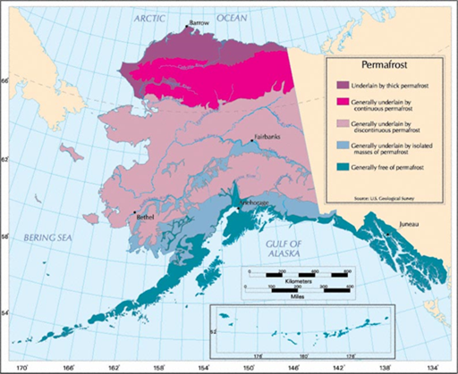

Figure 1. Alaska’s permafrost regions. Source: National Snow & Ice Data Center

### The Objectives

The purpose of this data analysis is to identify any possible temperature trends in Barrow, Alaska over the past 115 years. If such temperature trends are found, they will help inform Alaskan communities and policy-makers of the impacts of climate change in the northern Alaska region.

### Monthly Maximum Temperatures Trends: December, January, and February

Below is the raw climate data collected from the Barrow, AK station of NOAA/Earth System Laboratory, Global Monitoring Division, and NOAA’s Climate Data Center. The following graphs represent the trends in monthly maximum temperatures for December, January, and February over the course of 115 years from September 1, 1901 to January 21, 2017. These three consecutive months have shown the most significant warming trend out of all twelve months. Temperature trends, however, should be viewed with caution given that an estimated 12% of total data points are missing from the Barrow, AK climate dataset.

### December

The graph below shows that December maximum temperatures have warmed at a rate of 5.60 degrees per 100 years. The p-value of this upward trendline is 0.0022. In statistics, a p-value of less than 0.05 indicates that the trend is statistically significant. Therefore, we can reject the null hypothesis, which states that there is no long-term trend in December maximum temperatures.

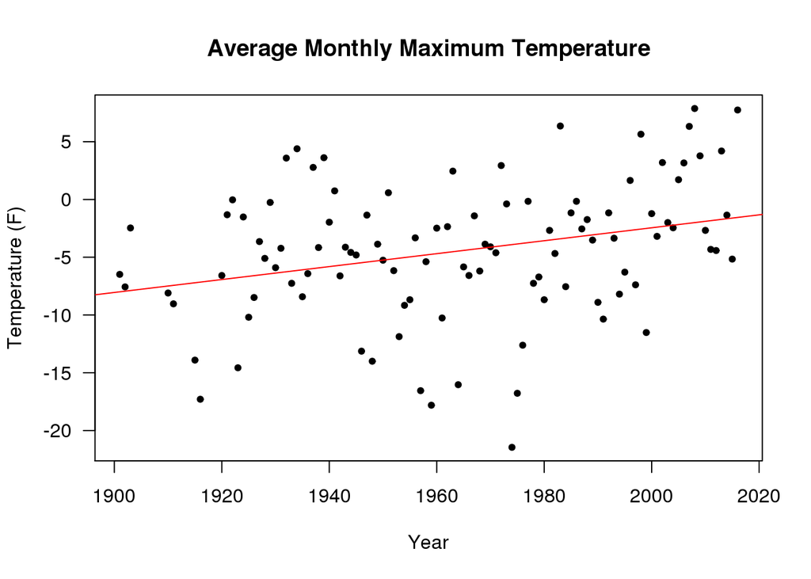

### January

The graph below shows that January maximum temperatures have warmed at a rate of 6.52 degrees per 100 years. The p-value of this upward trendline is 0.0035. In statistics, a p-value of less than 0.05 indicates that the trend is statistically significant. Therefore, we can reject the null hypothesis, which states that there is no long-term trend in January maximum temperatures.

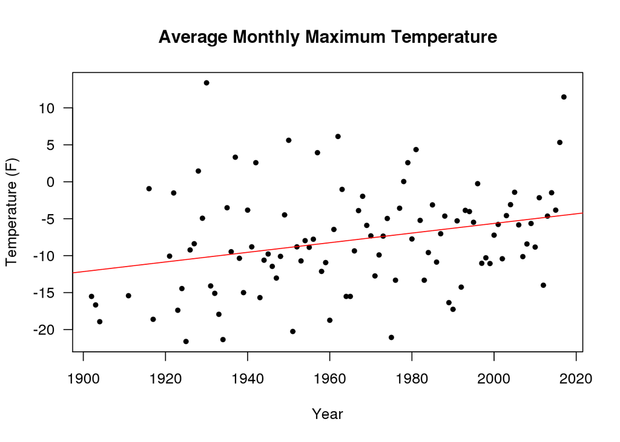

### February

The graph below shows that February maximum temperatures have warmed at a rate of 4.85 degrees per 100 years. The p-value of this upward trendline is 0.0467. In statistics, a p-value of less than 0.05 indicates that the trend is statistically significant. Therefore, we can reject the null hypothesis, which states that there is no long-term trend in February maximum temperatures.

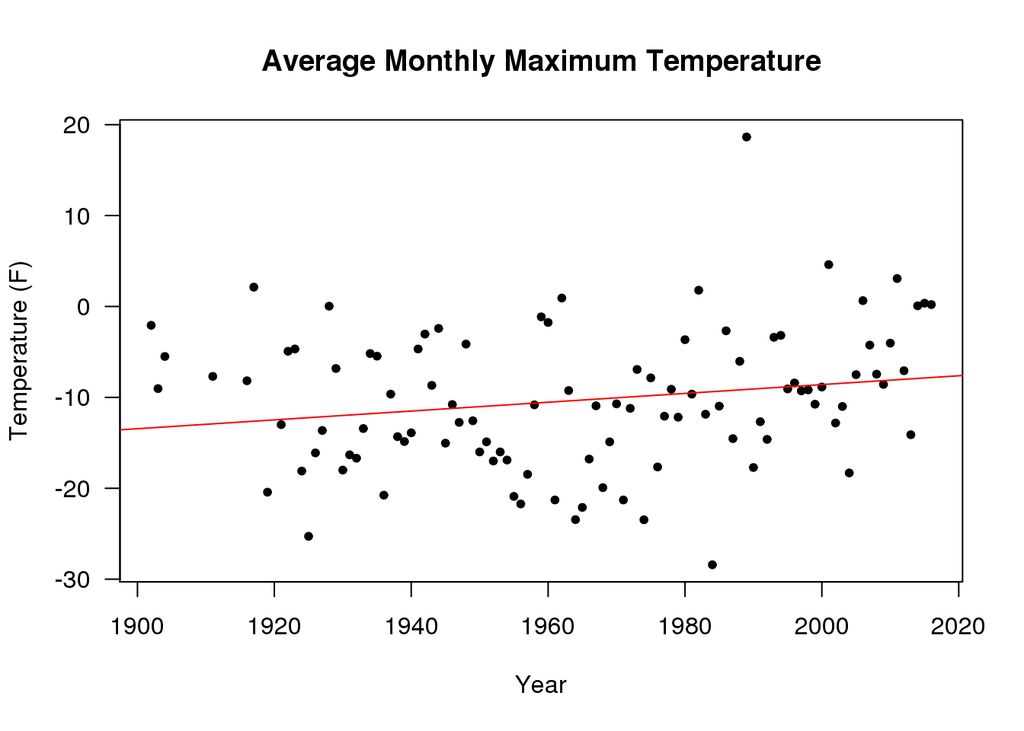

### Discussion

Winters in Barrow, Alaska have gotten significantly warmer over the past 115 years. For residents, this warming has been most visible in the form of thawing permafrost, receding sea ice, and melting snow and glaciers. The surface air temperatures observed in late 2016 and early 2017 are some of the highest on record, with 2017 marking the hottest January since the late 1920s. While rising winter temperatures in Barrow have resulted in some benefits such as a longer growing season, repercussions have also been making their presence known.

One notable implication is the melting of sea ice, which has brought about rising sea levels, coastal erosion, and infrastructure and habitat damage (Hinzman, et al., 2005). Furthermore, as permafrost thaws, organic matter decomposes, releasing huge amounts of carbon dioxide and methane into the atmosphere. This has transformed the Arctic tundra from a net sink for carbon into a major source of it. This issue of carbon emissions from thawing permafrost is compounded by the increase in wildfires observed throughout Alaska. More wildfires, in turn, will cause even more permafrost to melt, thus exacerbating the issue by sending more heat-trapping gases into the atmosphere (Hinzman, et al., 2005).

### Projected Trends for Barrow, Alaska

Alaska has already warmed more than twice as fast as the rest of the nation(U.S. Global Change Research Program, 2014). According to the U.S. National Climate Assessment, however, if CO2 emissions are not reduced by 2100, temperatures are expected to increase 10°F to 12°F in the Arctic region. Even if emissions are substantially reduced, temperatures in northern Alaska are still projected to increase 6°F to 8°F.

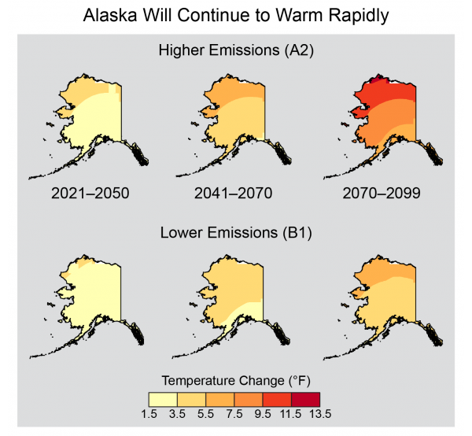

Figure 2. Alaska is projected to continue warming rapidly. Source: Regional Climate Trends and Scenarios for the U.S. National Climate Assessment: Part 7. Climate of Alaska. NOAA Technical Report NESDIS 142-7

With northern Alaska being entirely underlain by permafrost, the projected warming trends pose significant risks to northern communities such as the Iñupiaq of Barrow, Alaska (U.S. Global Change Research Program, 2014). Melting sea ice and thawing of permafrost are likely to create food and water security challenges and increase the vulnerability of coastal infrastructure and wildlife habitat. Many coastal communities, including Barrow, are considering moving miles inland to protect themselves from coastal dangers. However, relocation is a costly procedure and the state and federal government are reluctant to supply the funds. Additionally, moving inland would only be a temporary solution and would not solve the issues of food and water insecurity and melting permafrost as a threat to infrastructure (U.S. Global Change Research Program, 2014).

As a result of global greenhouse gas emissions, Barrow and other northern Alaska communities face numerous climactic challenges that are projected to intensify within the 21st century. Researchers and residents worry about the implications of a warming climate and the seemingly inevitable fate of their native land. Every year, conditions are worsening and coastal land is being lost (U.S. Global Change Research Program, 2014). It is time for the state and federal government to take notice of these communities, to ensure their safety, and to protect their environment.

### References

Cohen, J., Screen, J., Furtado, J. et al. “Recent Arctic amplification and extreme mid-latitude weather.” Nature Geoscience, (2014).

Comiso, J. C. and Hall, D. K. “Climate trends in the Arctic as observed from space.” WIREs Climate Change, 5: 389–409.

Euskirchen, E. S., et al. “Changes in vegetation in northern Alaska under scenarios of climate change, 2003–2100: implications for climate feedbacks.” Ecological Applications, 19 (2009): 1022–1043.

Herndon, E. M., et al. “Pathways of anaerobic organic matter decomposition in tundra soils from Barrow, Alaska”, J. Geophys. Res. Biogeosci. 120 (2015): 2345–2359.

Hezel, Paul J. “IPCC AR5 WGI: Polar Regions: Polar Amplification, Permafrost, Sea Ice Changes.” IPCC - Intergovernmental Panel on Climate Change. N.p., 2013. Web. 11 Feb. 2017.

Hinzman, L.D., Bettez, N.D., Bolton, W.R. et al. “Evidence and Implications of Recent Climate Change in Northern Alaska and Other Arctic Regions.” Climatic Change, 72 (2005): 251.

Hugelius, G., Strauss, J., Zubrzycki, S., Harden, J. W. et al. “Estimated stocks of circumpolar permafrost carbon with quantified uncertainty ranges and identified data gaps.” Biogeosciences, 11.23 (2014): 6573-6593.

Lara, Mark J., et al. “Polygonal tundra geomorphological change in response to warming alters future CO2 and CH4 flux on the Barrow Peninsula.” Global Change Biology, 21.4 (2015): 1634.

Overland, J. E., and M. Wang. “When will the summer Arctic be nearly sea ice free?” Geophys. Res. Lett., 40 (2013): 2097–2101.

Pastick, Neal J., et al. “Distribution of near-surface permafrost in Alaska: Estimates of present and future conditions, Remote Sensing of Environment.” 168 (2015): 301-315.

Reiss, Bob. “Welcome To Barrow, Alaska, Ground Zero For Climate Change.” Smithsonian 40.12 (2010): 58-66. Academic Search Premier. Web. 11 Feb. 2017.

Raz-Yaseef, N., et al. “Large CO2 and CH4 emissions from polygonal tundra during spring thaw in northern Alaska.” Geophys. Res. Lett., 44 (2017): 504–513.

Serreze, M.C., Walsh, J.E., Chapin, F.S. et al. Climatic Change. 46 (2000): 159.

Stone, R. S., E. G. Dutton, J. M. Harris, and D. Longenecker. “Earlier spring snowmelt in northern Alaska as an indicator of climate change.” J. Geophys. Res., 107 (2002).

U.S. Global Change Research Program. Climate Change Impacts in the United States: U.S. National Climate Assessment.Washington, DC: U.S. Global Change Research Program, 2014. Web.